# Regression Model for Metro Interstate Traffic Volume Using R Take 2

David Lowe

August 26, 2019

Template Credit: Adapted from a template made available by Dr. Jason Brownlee of Machine Learning Mastery. [http://machinelearningmastery.com/]

SUMMARY: The purpose of this project is to construct a predictive model using various machine learning algorithms and to document the end-to-end steps using a template. The Metro Interstate Traffic Volume is a regression situation where we are trying to predict a real-number value for a given set of criteria.

INTRODUCTION: This dataset captured the hourly measurement of Interstate 94 Westbound traffic volume for MN DoT ATR station 301. The station is roughly midway between Minneapolis and St Paul, MN. The dataset also included the hourly weather and holiday attributes for assessing their impacts on traffic volume.

In iteration Take1, we established the baseline mean squared error without much of feature engineering. This round of modeling also did not include the date-time and weather description attributes.

In this iteration, we will include the time stamp feature and observe its effect on the prediction accuracy.

ANALYSIS: From iteration Take1, the baseline performance of the machine learning algorithms achieved an average RMSE of 2099. Two algorithms (Random Forest and Gradient Boosting) achieved the top RMSE metrics after the first round of modeling. After a series of tuning trials, Gradient Boosting turned in the top overall result and achieved an RMSE metric of 1895. After applying the optimized parameters, the Gradient Boosting algorithm processed the testing dataset with an RMSE of 1899, which was slightly better than the prediction from the training data.

In the current iteration, the baseline performance of the machine learning algorithms achieved an average RMSE of 972. Two algorithms (Random Forest and Gradient Boosting) achieved the top RMSE metrics after the first round of modeling. After a series of tuning trials, Gradient Boosting turned in the top overall result and achieved an RMSE metric of 480. After applying the optimized parameters, the Gradient Boosting algorithm processed the testing dataset with an RMSE of 479, which was slightly better than the prediction from the training data.

Dataset Used: Metro Interstate Traffic Volume Data Set

Dataset ML Model: Regression with numerical and categorical attributes

Dataset Reference: https://archive.ics.uci.edu/ml/datasets/Metro+Interstate+Traffic+Volume

One potential source of performance benchmarks: https://www.kaggle.com/ramyahr/metro-interstate-traffic-volume

The project aims to touch on the following areas:

1. Document a predictive modeling problem end-to-end.
2. Explore data cleaning and transformation options
3. Explore non-ensemble and ensemble algorithms for baseline model performance
4. Explore algorithm tuning techniques for improving model performance

Any predictive modeling machine learning project genrally can be broken down into about six major tasks:

1. Prepare Environment
2. Summarize Data
3. Prepare Data
4. Model and Evaluate Algorithms
5. Improve Accuracy or Results
6. Finalize Model and Present Results

## 1. Prepare Environment

### 1.a) Load libraries and packages

```r
startTimeScript <- proc.time()
library(caret)
```

```r
library(corrplot)
library(DMwR)
library(Hmisc)
library(ROCR)
library(stringr)
```

### 1.b) Set up the controlling parameters and functions

```r
# Create the random seed number for reproducible results
seedNum <- 888

# Set up the notifyStatus flag to stop sending progress emails (setting to TRUE will send status emails!)
notifyStatus <- TRUE
if (notifyStatus) library(mailR)
# Run algorithms using 10-fold cross validation
control <- trainControl(method="repeatedcv", number=10, repeats=1)
metricTarget <- "RMSE"
```

```r
# Set up the email notification function
email_notify <- function(msg=""){
  sender <- Sys.getenv("MAIL_SENDER")
  receiver <- Sys.getenv("MAIL_RECEIVER")
  gateway <- Sys.getenv("SMTP_GATEWAY")
  smtpuser <- Sys.getenv("SMTP_USERNAME")
  password <- Sys.getenv("SMTP_PASSWORD")
  sbj_line <- "Notification from R Regression Modeling Script"
  send.mail(
    from = sender,
    to = receiver,
    subject= sbj_line,
    body = msg,
    smtp = list(host.name = gateway, port = 587, user.name = smtpuser, passwd = password, ssl = TRUE),
    authenticate = TRUE,
    send = TRUE)
}
```

```r
if (notifyStatus) email_notify(paste("Library and Data Loading has begun!",date()))
```

```
## [1] "Java-Object{org.apache.commons.mail.SimpleEmail@3b6eb2ec}"
```

### 1.c) Load dataset

```r
# Slicing up the document path to get the final destination file name
dataset_path <- 'https://archive.ics.uci.edu/ml/machine-learning-databases/00492/Metro_Interstate_Traffic_Volume.csv.gz'
doc_path_list <- str_split(dataset_path, "/")
# dest_file <- doc_path_list[[1]][length(doc_path_list[[1]])]
dest_file <- "Metro_Interstate_Traffic_Volume.csv"

if (!file.exists(dest_file)) {
  # Download the document from the website
  cat("Downloading", dataset_path, "as", dest_file, "\n")
  download.file(dataset_path, dest_file, mode = "wb")
  cat(dest_file, "downloaded!\n")
  unzip(dest_file)
  cat(dest_file, "unpacked!\n")
}

inputFile <- dest_file
Xy_original <- read.csv(dest_file, header = TRUE)
```

```r
# Take a peek at the dataframe after the import
head(Xy_original)
```

```
##   holiday   temp rain_1h snow_1h clouds_all weather_main
## 1    None 288.28       0       0         40       Clouds
## 2    None 289.36       0       0         75       Clouds
## 3    None 289.58       0       0         90       Clouds
## 4    None 290.13       0       0         90       Clouds
## 5    None 291.14       0       0         75       Clouds
## 6    None 291.72       0       0          1        Clear
##   weather_description           date_time traffic_volume
## 1    scattered clouds 2012-10-02 09:00:00           5545
## 2       broken clouds 2012-10-02 10:00:00           4516
## 3     overcast clouds 2012-10-02 11:00:00           4767
## 4     overcast clouds 2012-10-02 12:00:00           5026
## 5       broken clouds 2012-10-02 13:00:00           4918
## 6        sky is clear 2012-10-02 14:00:00           5181
```

```r
sapply(Xy_original, class)
```

```
##             holiday                temp             rain_1h
##            "factor"           "numeric"           "numeric"
##             snow_1h          clouds_all        weather_main
##           "numeric"           "integer"            "factor"
## weather_description           date_time      traffic_volume
##            "factor"            "factor"           "integer"
```

```r
sapply(Xy_original, function(x) sum(is.na(x)))
```

```
##             holiday                temp             rain_1h
##                   0                   0                   0
##             snow_1h          clouds_all        weather_main
##                   0                   0                   0
## weather_description           date_time      traffic_volume
##                   0                   0                   0
```

### 1.d) Data Cleaning

```r
# Create new columns from the date_time attribute
Xy_original$date_time <- strptime(Xy_original$date_time, "%Y-%m-%d %H:%M:%S")
Xy_original$date_month <- months(Xy_original$date_time)
Xy_original$date_month <- as.factor(Xy_original$date_month)
Xy_original$date_weekday <- weekdays(Xy_original$date_time)
Xy_original$date_weekday <- as.factor(Xy_original$date_weekday)
Xy_original$date_hour <- strftime(Xy_original$date_time, "%H")
Xy_original$date_hour <- as.factor(Xy_original$date_hour)
Xy_original$targetVar <- Xy_original$traffic_volume

# Drop un-needed features
Xy_original$date_time <- NULL
Xy_original$weather_description <- NULL
Xy_original$traffic_volume <- NULL
```

```r
# Take a peek at the dataframe after the cleaning
head(Xy_original)
```

```
##   holiday   temp rain_1h snow_1h clouds_all weather_main date_month
## 1    None 288.28       0       0         40       Clouds    October
## 2    None 289.36       0       0         75       Clouds    October
## 3    None 289.58       0       0         90       Clouds    October
## 4    None 290.13       0       0         90       Clouds    October
## 5    None 291.14       0       0         75       Clouds    October
## 6    None 291.72       0       0          1        Clear    October
##   date_weekday date_hour targetVar
## 1      Tuesday        09      5545
## 2      Tuesday        10      4516
## 3      Tuesday        11      4767
## 4      Tuesday        12      5026
## 5      Tuesday        13      4918
## 6      Tuesday        14      5181
```

```r
sapply(Xy_original, class)
```

```
##      holiday         temp      rain_1h      snow_1h   clouds_all
##     "factor"    "numeric"    "numeric"    "numeric"    "integer"
## weather_main   date_month date_weekday    date_hour    targetVar
##     "factor"     "factor"     "factor"     "factor"    "integer"
```

```r
sapply(Xy_original, function(x) sum(is.na(x)))
```

```
##      holiday         temp      rain_1h      snow_1h   clouds_all
##            0            0            0            0            0
## weather_main   date_month date_weekday    date_hour    targetVar
##            0            0            0            0            0
```

### 1.e) Splitting Data into Training and Test Sets

```r
# Use variable totCol to hold the number of columns in the dataframe
totCol <- ncol(Xy_original)

# Set up variable totAttr for the total number of attribute columns
totAttr <- totCol-1
```

```r
# targetCol variable indicates the column location of the target/class variable
# If the first column, set targetCol to 1. If the last column, set targetCol to totCol
# if (targetCol <> 1) and (targetCol <> totCol), be aware when slicing up the dataframes for visualization!
targetCol <- totCol

# Standardize the class column to the name of targetVar if applicable
colnames(Xy_original)[targetCol] <- "targetVar"
```

```r
# Create various sub-datasets for visualization and cleaning/transformation operations.
set.seed(seedNum)

# Use 75% of the data to train the models and the remaining for testing/validation
training_index <- createDataPartition(Xy_original$targetVar, p=0.75, list=FALSE)
Xy_train <- Xy_original[training_index,]
Xy_test <- Xy_original[-training_index,]

if (targetCol==1) {
  X_train <- Xy_train[,(targetCol+1):totCol]
  y_train <- Xy_train[,targetCol]
  y_test <- Xy_test[,targetCol]
} else {
  X_train <- Xy_train[,1:(totAttr)]
  y_train <- Xy_train[,totCol]
  y_test <- Xy_test[,totCol]
}
```

### 1.f) Set up the parameters for data visualization

```r
# Set up the number of row and columns for visualization display. dispRow * dispCol should be >= totAttr
dispCol <- 4
if (totAttr%%dispCol == 0) {
dispRow <- totAttr%/%dispCol
} else {
dispRow <- (totAttr%/%dispCol) + 1
}
cat("Will attempt to create graphics grid (col x row): ", dispCol, ' by ', dispRow)
```

```
## Will attempt to create graphics grid (col x row):  4  by  3
```

```r
if (notifyStatus) email_notify(paste("Library and Data Loading completed!",date()))
```

```
## [1] "Java-Object{org.apache.commons.mail.SimpleEmail@30c7da1e}"
```

## 2. Summarize Data

To gain a better understanding of the data that we have on-hand, we will leverage a number of descriptive statistics and data visualization techniques. The plan is to use the results to consider new questions, review assumptions, and validate hypotheses that we can investigate later with specialized models.

```r
if (notifyStatus) email_notify(paste("Data Summarization and Visualization has begun!",date()))
```

```
## [1] "Java-Object{org.apache.commons.mail.SimpleEmail@2812cbfa}"
```

### 2.a) Descriptive statistics

#### 2.a.i) Peek at the data itself

```r
head(Xy_train)
```

```
##    holiday   temp rain_1h snow_1h clouds_all weather_main date_month
## 2     None 289.36       0       0         75       Clouds    October
## 3     None 289.58       0       0         90       Clouds    October
## 4     None 290.13       0       0         90       Clouds    October
## 5     None 291.14       0       0         75       Clouds    October
## 8     None 293.86       0       0          1        Clear    October
## 11    None 290.97       0       0         20       Clouds    October
##    date_weekday date_hour targetVar
## 2       Tuesday        10      4516
## 3       Tuesday        11      4767
## 4       Tuesday        12      5026
## 5       Tuesday        13      4918
## 8       Tuesday        16      6015
## 11      Tuesday        19      3539
```

#### 2.a.ii) Dimensions of the dataset

```r
dim(Xy_train)
```

```
## [1] 36154    10
```

#### 2.a.iii) Types of the attribute

```r
sapply(Xy_train, class)
```

```
##      holiday         temp      rain_1h      snow_1h   clouds_all
##     "factor"    "numeric"    "numeric"    "numeric"    "integer"
## weather_main   date_month date_weekday    date_hour    targetVar
##     "factor"     "factor"     "factor"     "factor"    "integer"
```

#### 2.a.iv) Statistical summary of the attributes

```r
summary(Xy_train)
```

```
##                       holiday           temp          rain_1h
##  None                     :36104   Min.   :  0.0   Min.   :   0.000
##  Labor Day                :    7   1st Qu.:272.1   1st Qu.:   0.000
##  Christmas Day            :    5   Median :282.6   Median :   0.000
##  Columbus Day             :    5   Mean   :281.2   Mean   :   0.402
##  Martin Luther King Jr Day:    5   3rd Qu.:291.8   3rd Qu.:   0.000
##  Thanksgiving Day         :    5   Max.   :310.1   Max.   :9831.300
##  (Other)                  :   23
##     snow_1h            clouds_all      weather_main      date_month
##  Min.   :0.0000000   Min.   :  0.00   Clouds :11422   July    : 3570
##  1st Qu.:0.0000000   1st Qu.:  1.00   Clear  : 9975   May     : 3338
##  Median :0.0000000   Median : 64.00   Mist   : 4485   August  : 3280
##  Mean   :0.0001895   Mean   : 49.43   Rain   : 4249   December: 3250
##  3rd Qu.:0.0000000   3rd Qu.: 90.00   Snow   : 2176   April   : 3174
##  Max.   :0.5100000   Max.   :100.00   Drizzle: 1349   January : 3004
##                                       (Other): 2498   (Other) :16538
##     date_weekday    date_hour       targetVar
##  Friday   :5075   07     : 1580   Min.   :   0
##  Monday   :5316   04     : 1575   1st Qu.:1193
##  Saturday :5117   06     : 1562   Median :3380
##  Sunday   :5159   10     : 1557   Mean   :3259
##  Thursday :5138   08     : 1550   3rd Qu.:4933
##  Tuesday  :5149   01     : 1546   Max.   :7280
##  Wednesday:5200   (Other):26784
```

#### 2.a.v) Count missing values

```r
sapply(Xy_train, function(x) sum(is.na(x)))
```

```
##      holiday         temp      rain_1h      snow_1h   clouds_all
##            0            0            0            0            0
## weather_main   date_month date_weekday    date_hour    targetVar
##            0            0            0            0            0
```

### 2.b) Data visualizations

```r
# Boxplots for each attribute
# par(mfrow=c(dispRow,dispCol))
# for(i in 1:totAttr) {
#   boxplot(X_train[,i], main=names(X_train)[i])
# }
```

```r
# Histograms each attribute
# par(mfrow=c(dispRow,dispCol))
# for(i in 1:totAttr) {
#   hist(X_train[,i], main=names(X_train)[i])
# }
```

```r
# Density plot for each attribute
# par(mfrow=c(dispRow,dispCol))
# for(i in 1:totAttr) {
#   plot(density(X_train[,i]), main=names(X_train)[i])
# }
```

```r
# Correlation matrix
# correlations <- cor(X_train)
# corrplot(correlations, method="circle")
```

```r
if (notifyStatus) email_notify(paste("Data Summarization and Visualization completed!",date()))
```

```
## [1] "Java-Object{org.apache.commons.mail.SimpleEmail@2f7a2457}"
```

## 3. Prepare Data

Some dataset may require additional preparation activities that will best exposes the structure of the problem and the relationships between the input attributes and the output variable. Some data-prep tasks might include:

- Cleaning data by removing duplicates, marking missing values and even imputing missing values.
- Feature selection where redundant features may be removed.
- Data transforms where attributes are scaled or redistributed in order to best expose the structure of the problem later to learning algorithms.

```r
if (notifyStatus) email_notify(paste("Data Cleaning and Transformation has begun!",date()))
```

```
## [1] "Java-Object{org.apache.commons.mail.SimpleEmail@5ebec15}"
```

### 3.a) Data Transforms

```r
# Not applicable for this iteration of the project
```

### 3.b) Feature Selection

```r
# Not applicable for this iteration of the project
```

### 3.c) Display the Final Datasets for Model-Building

```r
# We finalize the training and testing datasets for the modeling activities
dim(Xy_train)
```

```
## [1] 36154    10
```

```r
dim(Xy_test)
```

```
## [1] 12050    10
```

```r
if (notifyStatus) email_notify(paste("Data Cleaning and Transformation completed!",date()))
```

```
## [1] "Java-Object{org.apache.commons.mail.SimpleEmail@38082d64}"
```

```r
proc.time()-startTimeScript
```

```
##    user  system elapsed
##   6.471   0.793  15.394
```

## 4. Model and Evaluate Algorithms

After the data-prep, we next work on finding a workable model by evaluating a subset of machine learning algorithms that are good at exploiting the structure of the dataset. The typical evaluation tasks include:

- Defining test options such as cross validation and the evaluation metric to use.
- Spot checking a suite of linear and nonlinear machine learning algorithms.
- Comparing the estimated accuracy of algorithms.

For this project, we will evaluate four linear, one non-linear, and three ensemble algorithms:

Linear Algorithms: Linear Regression, Ridge, The Lasso, Elasticnet

Non-Linear Algorithm: Decision Trees (CART)

Ensemble Algorithms: Bagged CART, Random Forest, and Gradient Boosting

The random number seed is reset before each run to ensure that the evaluation of each algorithm is performed using the same data splits. It ensures the results are directly comparable.

### 4.a) Generate models using linear algorithms

```r
startModeling <- proc.time()
```

```r
# Linear Regression (Regression)
if (notifyStatus) email_notify(paste("Linear Regression modeling has begun!",date()))
```

```
## [1] "Java-Object{org.apache.commons.mail.SimpleEmail@180bc464}"
```

```r
startTimeModule <- proc.time()
set.seed(seedNum)
fit.lm <- train(targetVar~., data=Xy_train, method="lm", metric=metricTarget, trControl=control)
print(fit.lm)
```

```
## Linear Regression
##
## 36154 samples
##     9 predictor
##
## No pre-processing
## Resampling: Cross-Validated (10 fold, repeated 1 times)
## Summary of sample sizes: 32539, 32539, 32539, 32539, 32538, 32538, ...
## Resampling results:
##
##   RMSE      Rsquared   MAE
##   1309.256  0.7567708  597.4876
##
## Tuning parameter 'intercept' was held constant at a value of TRUE
```

```r
proc.time()-startTimeModule
```

```
##    user  system elapsed
##   7.546   2.497   7.121
```

```r
if (notifyStatus) email_notify(paste("Linear Regression modeling completed!",date()))
```

```
## [1] "Java-Object{org.apache.commons.mail.SimpleEmail@2d554825}"
```

```r
# Ridge (Regression)
if (notifyStatus) email_notify(paste("Ridge Regression modeling has begun!",date()))
```

```
## [1] "Java-Object{org.apache.commons.mail.SimpleEmail@4909b8da}"
```

```r
startTimeModule <- proc.time()
set.seed(seedNum)
fit.ridge <- train(targetVar~., data=Xy_train, method="ridge", metric=metricTarget, trControl=control)
print(fit.ridge)
```

```
## Ridge Regression
##
## 36154 samples
##     9 predictor
##
## No pre-processing
## Resampling: Cross-Validated (10 fold, repeated 1 times)
## Summary of sample sizes: 32539, 32539, 32539, 32539, 32538, 32538, ...
## Resampling results across tuning parameters:
##
##   lambda  RMSE      Rsquared   MAE
##   0e+00   1309.256  0.7567708  597.4876
##   1e-04   1309.303  0.7567675  597.5778
##   1e-01   1407.540  0.7288844  644.5002
##
## RMSE was used to select the optimal model using the smallest value.
## The final value used for the model was lambda = 0.
```

```r
proc.time()-startTimeModule
```

```
##    user  system elapsed
##  67.709  44.756  58.723
```

```r
if (notifyStatus) email_notify(paste("Ridge Regression modeling completed!",date()))
```

```
## [1] "Java-Object{org.apache.commons.mail.SimpleEmail@54a097cc}"
```

```r
# The Lasso (Regression)
if (notifyStatus) email_notify(paste("The Lasso modeling has begun!",date()))
```

```
## [1] "Java-Object{org.apache.commons.mail.SimpleEmail@50f8360d}"
```

```r
startTimeModule <- proc.time()
set.seed(seedNum)
fit.lasso <- train(targetVar~., data=Xy_train, method="lasso", metric=metricTarget, trControl=control)
print(fit.lasso)
```

```
## The lasso
##
## 36154 samples
##     9 predictor
##
## No pre-processing
## Resampling: Cross-Validated (10 fold, repeated 1 times)
## Summary of sample sizes: 32539, 32539, 32539, 32539, 32538, 32538, ...
## Resampling results across tuning parameters:
##
##   fraction  RMSE       Rsquared   MAE
##   0.1       1646.7168  0.4954558  1458.8636
##   0.5        958.4148  0.7869662   731.0985
##   0.9       1267.4065  0.7566230   605.1499
##
## RMSE was used to select the optimal model using the smallest value.
## The final value used for the model was fraction = 0.5.
```

```r
proc.time()-startTimeModule
```

```
##    user  system elapsed
##  24.938  15.976  21.516
```

```r
if (notifyStatus) email_notify(paste("The Lasso modeling completed!",date()))
```

```
## [1] "Java-Object{org.apache.commons.mail.SimpleEmail@337d0578}"
```

```r
# Elasticnet (Regression)
if (notifyStatus) email_notify(paste("Elasticnet modeling has begun!",date()))
```

```
## [1] "Java-Object{org.apache.commons.mail.SimpleEmail@2669b199}"
```

```r
startTimeModule <- proc.time()
set.seed(seedNum)
fit.enet <- train(targetVar~., data=Xy_train, method="enet", metric=metricTarget, trControl=control)
print(fit.enet)
```

```
## Elasticnet
##
## 36154 samples
##     9 predictor
##
## No pre-processing
## Resampling: Cross-Validated (10 fold, repeated 1 times)
## Summary of sample sizes: 32539, 32539, 32539, 32539, 32538, 32538, ...
## Resampling results across tuning parameters:
##
##   lambda  fraction  RMSE       Rsquared   MAE
##   0e+00   0.050     1800.0714  0.4120673  1598.0642
##   0e+00   0.525      938.0862  0.7922930   710.1449
##   0e+00   1.000     1309.2563  0.7567708   597.4876
##   1e-04   0.050     1800.2916  0.4119980  1598.2523
##   1e-04   0.525      938.6105  0.7921527   710.6784
##   1e-04   1.000     1309.3031  0.7567675   597.5778
##   1e-01   0.050     1856.5701  0.3859976  1645.0140
##   1e-01   0.525     1129.3050  0.7352012   908.8316
##   1e-01   1.000     1407.5400  0.7288844   644.5002
##
## RMSE was used to select the optimal model using the smallest value.
## The final values used for the model were fraction = 0.525 and lambda = 0.
```

```r
proc.time()-startTimeModule
```

```
##    user  system elapsed
##  64.670  42.256  55.211
```

```r
if (notifyStatus) email_notify(paste("Elasticnet modeling completed!",date()))
```

```
## [1] "Java-Object{org.apache.commons.mail.SimpleEmail@3c756e4d}"
```

### 4.b) Generate models using nonlinear algorithms

```r
# Decision Tree - CART (Regression/Classification)
if (notifyStatus) email_notify(paste("Decision Tree modeling has begun!",date()))
```

```
## [1] "Java-Object{org.apache.commons.mail.SimpleEmail@4439f31e}"
```

```r
startTimeModule <- proc.time()
set.seed(seedNum)
fit.cart <- train(targetVar~., data=Xy_train, method="rpart", metric=metricTarget, trControl=control)
print(fit.cart)
```

```
## CART
##
## 36154 samples
##     9 predictor
##
## No pre-processing
## Resampling: Cross-Validated (10 fold, repeated 1 times)
## Summary of sample sizes: 32539, 32539, 32539, 32539, 32538, 32538, ...
## Resampling results across tuning parameters:
##
##   cp          RMSE      Rsquared   MAE
##   0.04070554  1431.879  0.4800758  1108.289
##   0.06299087  1494.443  0.4333707  1169.205
##   0.09856423  1631.659  0.3963304  1327.674
##
## RMSE was used to select the optimal model using the smallest value.
## The final value used for the model was cp = 0.04070554.
```

```r
proc.time()-startTimeModule
```

```
##    user  system elapsed
##  22.569   1.474  22.902
```

```r
if (notifyStatus) email_notify(paste("Decision Tree modeling completed!",date()))
```

```
## [1] "Java-Object{org.apache.commons.mail.SimpleEmail@2a2d45ba}"
```

### 4.c) Generate models using ensemble algorithms

In this section, we will explore the use and tuning of ensemble algorithms to see whether we can improve the results.

```r
# Bagged CART (Regression/Classification)
if (notifyStatus) email_notify(paste("Bagged CART modeling has begun!",date()))
```

```
## [1] "Java-Object{org.apache.commons.mail.SimpleEmail@457e2f02}"
```

```r
startTimeModule <- proc.time()
set.seed(seedNum)
fit.bagcart <- train(targetVar~., data=Xy_train, method="treebag", metric=metricTarget, trControl=control)
print(fit.bagcart)
```

```
## Bagged CART
##
## 36154 samples
##     9 predictor
##
## No pre-processing
## Resampling: Cross-Validated (10 fold, repeated 1 times)
## Summary of sample sizes: 32539, 32539, 32539, 32539, 32538, 32538, ...
## Resampling results:
##
##   RMSE      Rsquared   MAE
##   783.2425  0.8444967  517.1024
```

```r
proc.time()-startTimeModule
```

```
##    user  system elapsed
## 197.985  25.994 194.778
```

```r
if (notifyStatus) email_notify(paste("Bagged CART modeling completed!",date()))
```

```
## [1] "Java-Object{org.apache.commons.mail.SimpleEmail@cb5822}"
```

```r
# Random Forest (Regression/Classification)
if (notifyStatus) email_notify(paste("Random Forest modeling has begun!",date()))
```

```
## [1] "Java-Object{org.apache.commons.mail.SimpleEmail@28d25987}"
```

```r
startTimeModule <- proc.time()
set.seed(seedNum)
fit.rf <- train(targetVar~., data=Xy_train, method="rf", metric=metricTarget, trControl=control)
print(fit.rf)
```

```
## Random Forest
##
## 36154 samples
##     9 predictor
##
## No pre-processing
## Resampling: Cross-Validated (10 fold, repeated 1 times)
## Summary of sample sizes: 32539, 32539, 32539, 32539, 32538, 32538, ...
## Resampling results across tuning parameters:
##
##   mtry  RMSE       Rsquared   MAE
##    2    1441.8275  0.7883432  1248.3252
##   33     474.6530  0.9428096   269.3005
##   65     481.7078  0.9410914   271.5169
##
## RMSE was used to select the optimal model using the smallest value.
## The final value used for the model was mtry = 33.
```

```r
proc.time()-startTimeModule
```

```
##      user    system   elapsed
## 84428.256     4.636 84639.878
```

```r
if (notifyStatus) email_notify(paste("Random Forest modeling completed!",date()))
```

```
## [1] "Java-Object{org.apache.commons.mail.SimpleEmail@59f99ea}"
```

```r
# Gradient Boosting (Regression/Classification)
if (notifyStatus) email_notify(paste("Gradient Boosting modeling has begun!",date()))
```

```
## [1] "Java-Object{org.apache.commons.mail.SimpleEmail@5c3bd550}"
```

```r
startTimeModule <- proc.time()
set.seed(seedNum)
fit.gbm <- train(targetVar~., data=Xy_train, method="xgbTree", metric=metricTarget, trControl=control, verbose=F)
# fit.gbm <- train(targetVar~., data=Xy_train, method="gbm", metric=metricTarget, trControl=control, verbose=F)
print(fit.gbm)
```

```
## eXtreme Gradient Boosting
##
## 36154 samples
##     9 predictor
##
## No pre-processing
## Resampling: Cross-Validated (10 fold, repeated 1 times)
## Summary of sample sizes: 32539, 32539, 32539, 32539, 32538, 32538, ...
## Resampling results across tuning parameters:
##
##   eta  max_depth  colsample_bytree  subsample  nrounds  RMSE
##   0.3  1          0.6               0.50        50      1190.8288
##   0.3  1          0.6               0.50       100      1011.6349
##   0.3  1          0.6               0.50       150       946.2278
##   0.3  1          0.6               0.75        50      1191.6177
##   0.3  1          0.6               0.75       100      1013.6276
##   0.3  1          0.6               0.75       150       947.6884
##   0.3  1          0.6               1.00        50      1193.1987
##   0.3  1          0.6               1.00       100      1015.4535
##   0.3  1          0.6               1.00       150       949.8287
##   0.3  1          0.8               0.50        50      1189.1931
##   0.3  1          0.8               0.50       100      1009.8654
##   0.3  1          0.8               0.50       150       944.0223
##   0.3  1          0.8               0.75        50      1191.4853
##   0.3  1          0.8               0.75       100      1012.6014
##   0.3  1          0.8               0.75       150       946.4133
##   0.3  1          0.8               1.00        50      1192.6923
##   0.3  1          0.8               1.00       100      1014.6547
##   0.3  1          0.8               1.00       150       949.0289
##   0.3  2          0.6               0.50        50       907.2338
##   0.3  2          0.6               0.50       100       752.4559
##   0.3  2          0.6               0.50       150       700.5784
##   0.3  2          0.6               0.75        50       916.7695
##   0.3  2          0.6               0.75       100       758.7462
##   0.3  2          0.6               0.75       150       704.9393
##   0.3  2          0.6               1.00        50       913.4365
##   0.3  2          0.6               1.00       100       760.9527
##   0.3  2          0.6               1.00       150       706.9732
##   0.3  2          0.8               0.50        50       894.9026
##   0.3  2          0.8               0.50       100       739.6094
```

[output cut: 181 more lines]

```
##   0.9154395  356.6170
##   0.8813090  451.4834
##   0.9032886  384.8958
##   0.9145430  357.7292
##   0.8796750  456.3715
##   0.9022226  386.7531
##   0.9136883  358.7342
##
## Tuning parameter 'gamma' was held constant at a value of 0
##
## Tuning parameter 'min_child_weight' was held constant at a value of 1
## RMSE was used to select the optimal model using the smallest value.
## The final values used for the model were nrounds = 150, max_depth = 3,
##  eta = 0.4, gamma = 0, colsample_bytree = 0.8, min_child_weight = 1
##  and subsample = 0.5.
```

```r
proc.time()-startTimeModule
```

```
##     user   system  elapsed
## 2107.121    5.704 1085.242
```

```r
if (notifyStatus) email_notify(paste("Gradient Boosting modeling completed!",date()))
```

```
## [1] "Java-Object{org.apache.commons.mail.SimpleEmail@39c0f4a}"
```

### 4.d) Compare baseline algorithms

```r
results <- resamples(list(LR=fit.lm, RIDGE=fit.ridge, LASSO=fit.lasso, ENET=fit.enet, CART=fit.cart, BagCART=fit.bagcart, RF=fit.rf, GBM=fit.gbm))
summary(results)
```

```
##
## Call:
## summary.resamples(object = results)
##
## Models: LR, RIDGE, LASSO, ENET, CART, BagCART, RF, GBM
## Number of resamples: 10
##
## MAE
##              Min.   1st Qu.    Median      Mean   3rd Qu.      Max. NA's
## LR       572.6778  578.3245  586.3722  597.4876  599.1459  694.7484    0
## RIDGE    572.6778  578.3245  586.3722  597.4876  599.1459  694.7484    0
## LASSO    721.7800  724.5508  730.7586  731.0985  737.3908  742.2858    0
## ENET     699.7810  703.9300  709.4967  710.1449  717.3581  721.0448    0
## CART    1077.8969 1084.1278 1108.4397 1108.2894 1132.5720 1142.9028    0
## BagCART  507.5979  511.9456  514.6336  517.1024  521.4978  533.3935    0
## RF       257.4924  263.1788  268.8927  269.3005  275.4547  280.4629    0
## GBM      339.8555  351.1461  357.3871  356.6170  361.6800  369.1887    0
##
## RMSE
##              Min.   1st Qu.    Median      Mean   3rd Qu.      Max. NA's
## LR       790.6605  800.3461  813.3234 1309.2563  824.5258 5799.0480    0
## RIDGE    790.6605  800.3461  813.3234 1309.2563  824.5258 5799.0480    0
## LASSO    948.3628  951.7110  957.2171  958.4148  963.3431  971.9032    0
## ENET     926.4641  931.2715  937.2004  938.0862  943.1657  952.4865    0
## CART    1394.9557 1403.4805 1428.7598 1431.8793 1459.5956 1480.6393    0
## BagCART  757.9855  776.9671  782.7746  783.2425  790.7790  803.9599    0
## RF       435.8319  463.7188  472.0763  474.6530  480.3627  516.5653    0
## GBM      541.7357  567.6938  576.3868  578.6851  587.4409  623.6842    0
##
## Rsquared
##               Min.   1st Qu.    Median      Mean   3rd Qu.      Max. NA's
## LR      0.06783272 0.8286984 0.8322358 0.7567708 0.8359611 0.8416375    0
## RIDGE   0.06783272 0.8286984 0.8322358 0.7567708 0.8359611 0.8416375    0
## LASSO   0.77908632 0.7842443 0.7864113 0.7869662 0.7891870 0.7964251    0
## ENET    0.78421984 0.7897624 0.7917033 0.7922930 0.7941802 0.8019871    0
## CART    0.45067228 0.4631095 0.4813201 0.4800758 0.4995403 0.5040973    0
## BagCART 0.83766371 0.8417637 0.8444497 0.8444967 0.8473123 0.8531833    0
## RF      0.93180044 0.9416112 0.9434469 0.9428096 0.9451538 0.9521009    0
## GBM     0.90060549 0.9136209 0.9163769 0.9154395 0.9183792 0.9266040    0
```

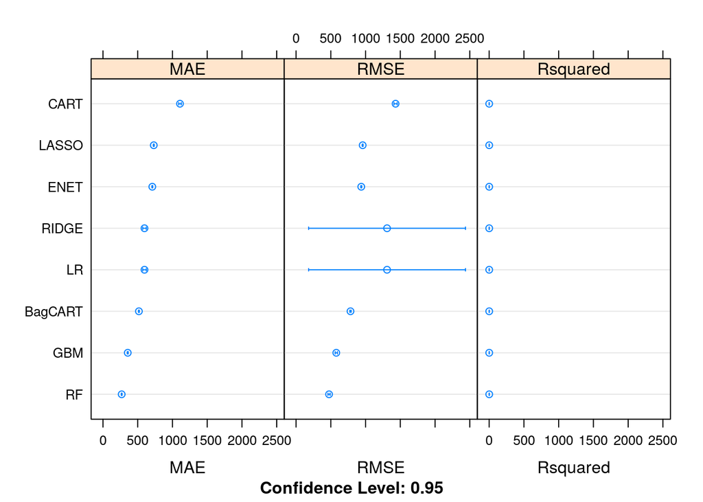

```r
dotplot(results)
```

```r
cat('The average RMSE from all models is:',
    mean(c(results$values$`LR~RMSE`,results$values$`RIDGE~RMSE`,results$values$`LASSO~RMSE`,results$values$`ENET~RMSE`,results$values$`CART~RMSE`,results$values$`BagCART~RMSE`,results$values$`RF~RMSE`,results$values$`GBM~RMSE`)),'\n')
```

```
## The average RMSE from all models is: 972.9342
```

```r
cat('Total training time for all models:',proc.time()-startModeling)
```

```
## Total training time for all models: 86927.2 143.493 86115.46 0 0
```

## 5. Improve Accuracy or Results

After we achieve a short list of machine learning algorithms with good level of accuracy, we can leverage ways to improve the accuracy of the models.

### 5.a) Algorithm Tuning

Finally, we will tune the best-performing algorithms from each group further and see whether we can get more accuracy out of them.

```r
# Tuning algorithm #1 - Random Forest
if (notifyStatus) email_notify(paste("Algorithm #1 tuning has begun!",date()))
```

```
## [1] "Java-Object{org.apache.commons.mail.SimpleEmail@e25b2fe}"
```

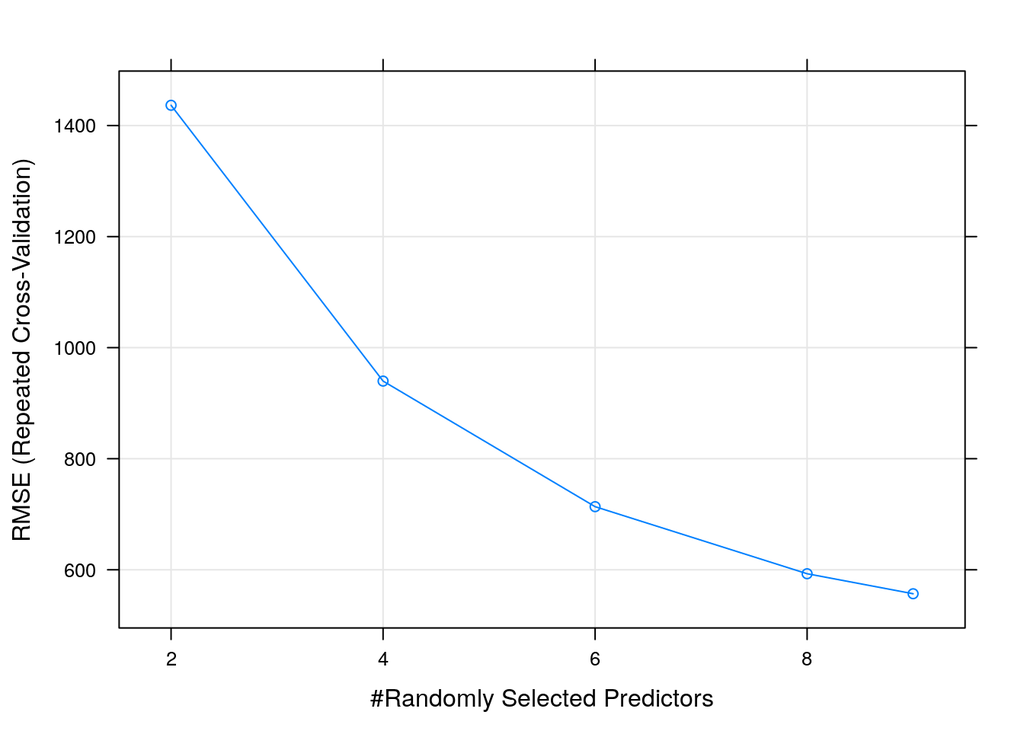

```r
startTimeModule <- proc.time()
set.seed(seedNum)
grid <- expand.grid(mtry = c(2,4,6,8,9))
fit.final1 <- train(targetVar~., data=Xy_train, method="rf", metric=metricTarget, tuneGrid=grid, trControl=control)
plot(fit.final1)
```

```r
print(fit.final1)
```

```
## Random Forest
##
## 36154 samples
##     9 predictor
##
## No pre-processing
## Resampling: Cross-Validated (10 fold, repeated 1 times)
## Summary of sample sizes: 32539, 32539, 32539, 32539, 32538, 32538, ...
## Resampling results across tuning parameters:
##
##   mtry  RMSE       Rsquared   MAE
##   2     1436.4652  0.7882399  1243.0636
##   4      939.7826  0.8465761   750.0139
##   6      713.6359  0.8877704   504.6040
##   8      592.8718  0.9160545   388.3987
##   9      556.8514  0.9244932   356.2859
##
## RMSE was used to select the optimal model using the smallest value.
## The final value used for the model was mtry = 9.
```

```r
proc.time()-startTimeModule
```

```
##      user    system   elapsed
## 13540.507    12.733 13585.158
```

```r
if (notifyStatus) email_notify(paste("Algorithm #1 tuning completed!",date()))
```

```
## [1] "Java-Object{org.apache.commons.mail.SimpleEmail@598067a5}"
```

```r
# Tuning algorithm #2 - Gradient Boosting
if (notifyStatus) email_notify(paste("Algorithm #2 tuning has begun!",date()))
```

```
## [1] "Java-Object{org.apache.commons.mail.SimpleEmail@4cf777e8}"
```

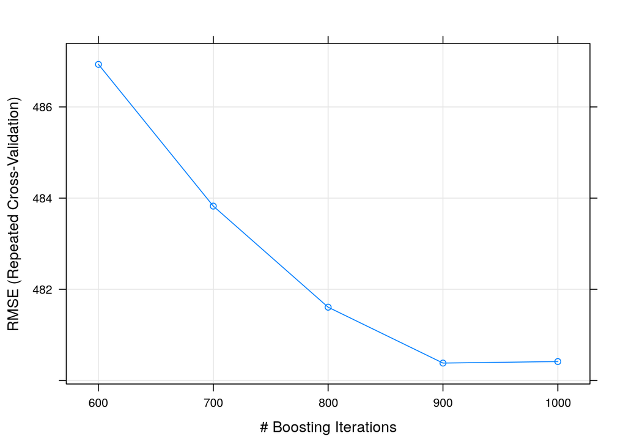

```r
startTimeModule <- proc.time()
set.seed(seedNum)
grid <- expand.grid(nrounds=c(600,700,800,900,1000), max_depth=3, eta=0.4, gamma=0, colsample_bytree=0.8, min_child_weight=1, subsample=0.5)
fit.final2 <- train(targetVar~., data=Xy_train, method="xgbTree", metric=metricTarget, tuneGrid=grid, trControl=control, verbose=F)
plot(fit.final2)
```

```r
print(fit.final2)
```

[output not shown]

```r
proc.time()-startTimeModule
```

```
##    user  system elapsed
## 643.923   1.315 326.008
```

```r
if (notifyStatus) email_notify(paste("Algorithm #2 tuning completed!",date()))
```

```
## [1] "Java-Object{org.apache.commons.mail.SimpleEmail@3f49dace}"
```

### 5.d) Compare Algorithms After Tuning

```r
results <- resamples(list(RF=fit.final1, GBM=fit.final2))
summary(results)
```

```
##
## Call:
## summary.resamples(object = results)
##
## Models: RF, GBM
## Number of resamples: 10
##
## MAE
##         Min.  1st Qu.   Median     Mean  3rd Qu.     Max. NA's
## RF  344.4075 351.3373 357.7484 356.2859 360.5415 367.1789    0
## GBM 288.2749 295.9315 301.5465 299.7340 303.9680 306.6531    0
##
## RMSE
##         Min.  1st Qu.   Median     Mean  3rd Qu.     Max. NA's
## RF  526.5777 543.9070 557.2925 556.8514 560.5135 598.5677    0
## GBM 450.9917 471.7151 479.9643 480.3834 488.5893 519.2495    0
##
## Rsquared
##          Min.   1st Qu.    Median      Mean   3rd Qu.      Max. NA's
## RF  0.9102057 0.9236910 0.9245412 0.9244932 0.9281327 0.9342637    0
## GBM 0.9310671 0.9397411 0.9417390 0.9414452 0.9435527 0.9485681    0
```

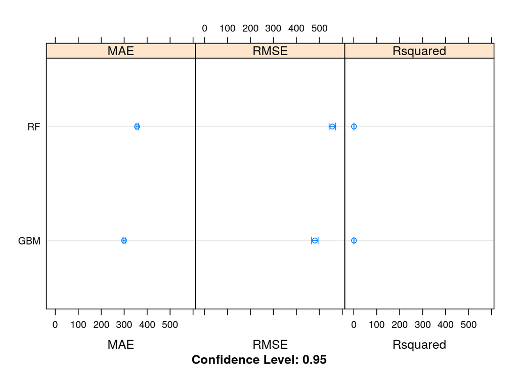

```r
dotplot(results)
```

## 6. Finalize Model and Present Results

Once we have narrow down to a model that we believe can make accurate predictions on unseen data, we are ready to finalize it. Finalizing a model may involve sub-tasks such as:

- Using an optimal model tuned to make predictions on unseen data.
- Creating a standalone model using the tuned parameters
- Saving an optimal model to file for later use.

```r
if (notifyStatus) email_notify(paste("Model Validation and Final Model Creation has begun!",date()))
```

```
## [1] "Java-Object{org.apache.commons.mail.SimpleEmail@56ef9176}"
```

### 6.a) Predictions on validation dataset

```r
predictions <- predict(fit.final1, newdata=Xy_test)
cat("The RMSE for the test data is:", RMSE(predictions, y_test),'\n')
```

```
## The RMSE for the test data is: 551.614
```

```r
cat("The R2 score for the model is:", R2(predictions, y_test))
```

```
## The R2 score for the model is: 0.9265603
```

```r
predictions <- predict(fit.final2, newdata=Xy_test)
cat("The RMSE for the test data is:", RMSE(predictions, y_test),'\n')
```

```
## The RMSE for the test data is: 479.477
```

```r
cat("The R2 score for the model is:", R2(predictions, y_test))
```

```
## The R2 score for the model is: 0.9419147
```

### 6.b) Create standalone model on entire training dataset

```r
startTimeModule <- proc.time()
set.seed(seedNum)

# Combining datasets to form a complete dataset that will be used to train the final model
Xy_complete <- rbind(Xy_train, Xy_test)

# library(xgboost)
# finalModel <- xgboost(data=Xy_complete, label=Xy_complete$targetVar, nrounds=900, max_depth=3, eta=0.4, gamma=0, colsample_bytree=0.8, min_child_weight=1, subsample=0.5)
# summary(finalModel)
proc.time()-startTimeModule
```

```
##    user  system elapsed
##   0.026   0.000   0.026
```

### 6.c) Save model for later use

```r
#saveRDS(finalModel, "./finalModel_Regression.rds")
```

```r
if (notifyStatus) email_notify(paste("Model Validation and Final Model Creation Completed!",date()))
```

```
## [1] "Java-Object{org.apache.commons.mail.SimpleEmail@5649fd9b}"
```

```r
proc.time()-startTimeScript
```

```
##       user     system    elapsed
## 101123.100    158.404 100055.916
```